# South Florida COVID-19 Trajectory

Roy Williams, Gabriel J. Odom, Zoran Bursac, and Mary Jo Trepka

23 June 2020

# Introduction

Public understanding of science is critical in times of crisis. The following analysis was conducted to examine the trajectory of COVID-19 in the South Florida counties of Miami-Dade, Broward, and Palm Beach. For phased reopening, The White House has set guidelines for local municipalities in their “Opening Up American Again” report. In the report, it is highly suggested that:

1. Local areas show a downward trajectory in the number of positive cases as a percent of total tests over a two-week period, and
2. Local hospitals have capacity to handle all patients without crisis care.

The analysis begins by looking at the number of new positive cases each day and the number of total tests performed each day. The figures are presented together because **as there is more testing, there are likely to be more positive test results**. Therefore, the proportion of positive cases is also calculated. Given a flat or increasing number of tests performed, **the proportion of positive cases is the key metric to be used when looking at epidemic trajectory**. It is recommended that this proportion not exceed 5%.

Finally, to ensure hospitals can meet demand without crisis care, the COVID-19 positive hospitalization census, COVID-19 positive ICU census, and COVID-19 positive ventilation census is plotted over time. Census refers to the number of COVID-19 positive patients in the hospital, ICU, and on ventilators, respectively, on a given day.

For Miami-Dade, Broward, and Palm Beach Counties, this document shows the

- Full testing counts data,
- Count of positive and total COVID-19 tests since mid-March,
- Proportion of positive counts to total counts within the last two weeks,
- Proportion of positive counts to total counts since mid-March,
- Full COVID-19 hospitalization census data, and
- Counts of patients hospitalized with COVID-19 since the beginning of April

# Miami-Dade County

## COVID-19 Testing Data

### Full Data

This is a table of the most recent data we have available. We include data sources at the end of the document.

| Date | Positive | Negative | PropPositive |
| --- | --- | --- | --- |
| 20-Mar | 37 | 634 | 5.5141580 |
| 21-Mar | 46 | 373 | 10.9785203 |
| 22-Mar | 59 | 269 | 17.9878049 |
| 23-Mar | 50 | 365 | 12.0481928 |
| 24-Mar | 89 | 433 | 17.0498084 |
| 25-Mar | 124 | 1097 | 10.1556102 |
| 26-Mar | 163 | 668 | 19.6149218 |
| 27-Mar | 215 | 1100 | 16.3498099 |
| 28-Mar | 252 | 945 | 21.0526316 |
| 30-Mar | 509 | 1913 | 21.0156895 |
| 31-Mar | 422 | 1154 | 26.7766497 |
| 1-Apr | 79 | 688 | 10.2998696 |
| 2-Apr | 544 | 2413 | 18.3970240 |
| 3-Apr | 625 | 1878 | 24.9700360 |
| 4-Apr | 531 | 2521 | 17.3984273 |
| 5-Apr | 311 | 1260 | 19.7963081 |
| 6-Apr | 556 | 2309 | 19.4066318 |
| 7-Apr | 493 | 1990 | 19.8550141 |
| 8-Apr | 488 | 1113 | 30.4809494 |
| 9-Apr | 435 | 2636 | 14.1647672 |
| 10-Apr | 542 | 2505 | 17.7879882 |
| 11-Apr | 563 | 2732 | 17.0864947 |
| 12-Apr | 364 | 1614 | 18.4024267 |
| 13-Apr | 477 | 2267 | 17.3833819 |
| 14-Apr | 364 | 1663 | 17.9575728 |
| 15-Apr | 438 | 2392 | 15.4770318 |
| 16-Apr | 536 | 2767 | 16.2276718 |
| 17-Apr | 519 | 2901 | 15.1754386 |
| 18-Apr | 296 | 1509 | 16.3988920 |
| 19-Apr | 465 | 2690 | 14.7385103 |

[output cut: 64 more lines]

### Total COVID-19 Tests by Day

The average number of COVID-19 tests performed each day has doubled from about 2,000 in early April to over 4,500 in mid-June. On average, from March 30th until June 22nd, there was an increase of approximately 34 addition tests performed each day over the previous day. This data is presented on a log scale.

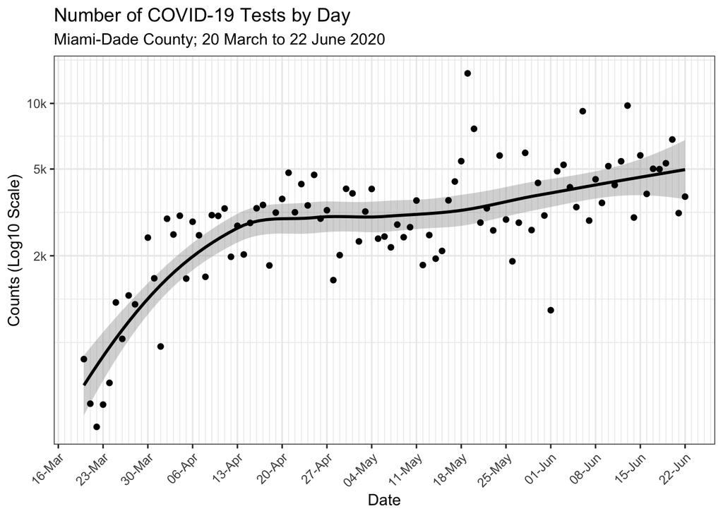

### Positive COVID-19 Tests by Day

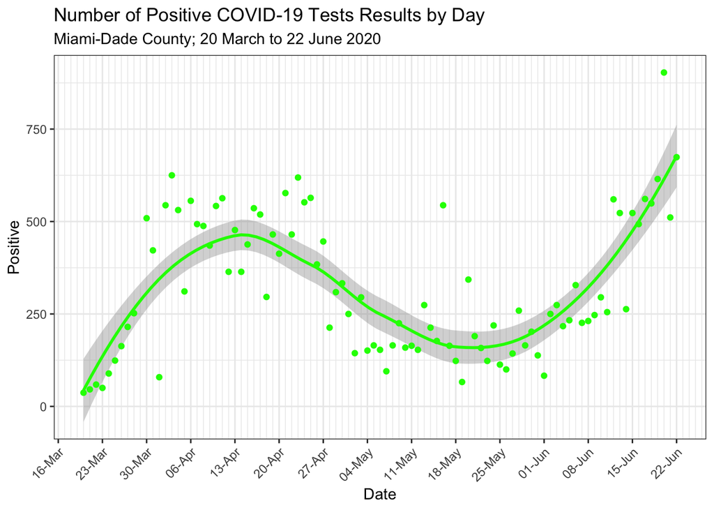

### Proportion of Positive Cases within Past Two Weeks

During the 14-day period from 08 June to 22 June, there was a **significant increase** in the proportion of positive COVID-19 cases reported in Miami-Dade County. Over this period, there was an average increase of 0.8 percentage points per day for new positive cases. This increase was even greater during the last week. Given a flat or increasing number of tests performed, the proportion of positive tests obtained is the **key metric** for examining COVID-19 trajectory. **The percentage of positive test results obtained has exceeded the 5% positive threshold recommended by the World Health Organization (WHO) for reopening.**

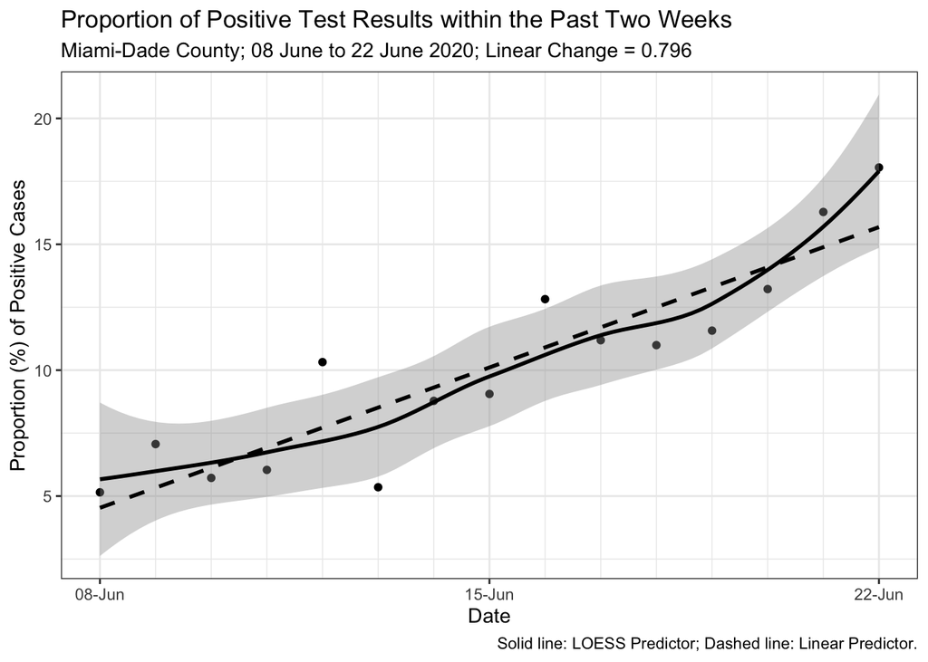

### Proportion of Positive COVID-19 Tests by Day

Overall, the proportion of positive test results out of all tests **decreased significantly** from over 20% in April to the proportion of about 5% at the end of May. This is function of test availability and the population being tested. Overall, since the county reopened, the proportion of positive tests is now **increasing significantly** over time.

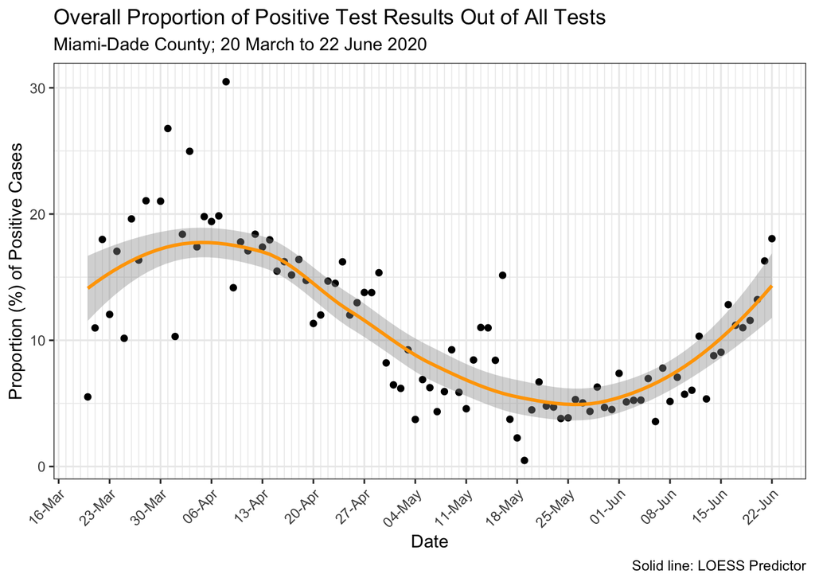

## COVID-19 Hospitalization Data

### Full Data

The data below is COVID-19 hospital census data for Miami-Dade County for all dates with available data since April 2.These columns are: the number of patients hospitalized with COVID-19 (**Hospitalised**), the number of patients in intensive care with COVID-19 (**ICU**), the number of patients in intensive care with COVID-19 who are also on ventilators (**Ventilated**), the number of patients positive for COVID-19 that were admitted the previous day (**AdmitPrevDay**), the number of patients recovered from COVID-19 that were discharged the previous day (**DischPrevDay**), and the net admission of patients positive for COVID-19 the previous day (**DeltaAdmit**; a negative value means more recovered patients were discharged than sick patients admitted).

| Date | County | Hospitalized | ICU | Ventilated | AdmitPrevDay | DischPrevDay | DeltaAdmit |
| --- | --- | --- | --- | --- | --- | --- | --- |
| 2020-04-02 | MIAMI-DADE | 320 | 130 | 116 | NA | NA | NA |
| 2020-04-03 | MIAMI-DADE | 346 | 133 | 116 | 111 | 33 | 78 |
| 2020-04-04 | MIAMI-DADE | 416 | 133 | 112 | 59 | 37 | 22 |
| 2020-04-05 | MIAMI-DADE | 533 | 188 | 146 | 108 | 19 | 89 |
| 2020-04-06 | MIAMI-DADE | 516 | 178 | 151 | 89 | 21 | 68 |
| 2020-04-07 | MIAMI-DADE | 591 | 199 | 167 | 76 | 28 | 48 |
| 2020-04-08 | MIAMI-DADE | 636 | 215 | 166 | 107 | 32 | 75 |
| 2020-04-09 | MIAMI-DADE | 634 | 232 | 170 | 99 | 61 | 38 |
| 2020-04-10 | MIAMI-DADE | 681 | 245 | 172 | 79 | 37 | 42 |
| 2020-04-10 | MIAMI-DADE | 676 | 251 | 183 | 73 | 36 | 37 |
| 2020-04-11 | MIAMI-DADE | 671 | 238 | 177 | 99 | 64 | 35 |
| 2020-04-12 | MIAMI-DADE | 672 | 243 | 192 | 80 | 59 | 21 |
| 2020-04-12 | MIAMI-DADE | 714 | 245 | 183 | 60 | 61 | -1 |
| 2020-04-13 | MIAMI-DADE | 653 | 247 | 184 | 74 | 47 | 27 |
| 2020-04-13 | MIAMI-DADE | 695 | 251 | 184 | 80 | 48 | 32 |
| 2020-04-14 | MIAMI-DADE | 653 | 204 | 146 | 69 | 41 | 28 |
| 2020-04-14 | MIAMI-DADE | 712 | 249 | 174 | 86 | 66 | 20 |
| 2020-04-15 | MIAMI-DADE | 693 | 234 | 169 | 84 | 76 | 8 |
| 2020-04-16 | MIAMI-DADE | 714 | 223 | 176 | 77 | 84 | -7 |
| 2020-04-16 | MIAMI-DADE | 736 | 226 | 176 | 74 | 111 | -37 |
| 2020-04-17 | MIAMI-DADE | 706 | 213 | 172 | 83 | 107 | -24 |
| 2020-04-17 | MIAMI-DADE | 797 | 285 | 170 | 74 | 88 | -14 |
| 2020-04-18 | MIAMI-DADE | 697 | 221 | 170 | 101 | 137 | -36 |
| 2020-04-18 | MIAMI-DADE | 697 | 219 | 170 | 93 | 138 | -45 |
| 2020-04-19 | MIAMI-DADE | 730 | 223 | 170 | 71 | 105 | -34 |
| 2020-04-20 | MIAMI-DADE | 727 | 210 | 167 | 58 | 64 | -6 |
| 2020-04-21 | MIAMI-DADE | 759 | 205 | 155 | 92 | 81 | 11 |
| 2020-04-22 | MIAMI-DADE | 743 | 196 | 148 | 72 | 88 | -16 |
| 2020-04-22 | MIAMI-DADE | 722 | 194 | 139 | 71 | 121 | -50 |
| 2020-04-23 | MIAMI-DADE | 706 | 186 | 129 | 91 | 62 | 29 |

[output cut: 70 more lines]